# Week 7: Tidy Data / Relational Data - Class Exercises

We first load the packages necessary for this exercise.

```python
import pandas as pd
import matplotlib.pyplot as plt
from itables import show
```

## 1. International Visitor Arrivals in Singapore

In this question, we revisit the tourist data we came across previously.  
The file `tourist.csv` (available from `Canvas > Files > data`) contains monthly international visitor arrivals by length of stay from July to December in 2023, retrieved from the Singapore Department of Statistics.  
Let’s start by reading in the data as `df`.

```python
# data for q1
df = pd.read_csv('../data/tourist.csv')
print(df)
```

```
       Data Series  2023 Dec  2023 Nov  2023 Oct  2023 Sep  2023 Aug  2023 Jul
0      Under 1 Day    259568    240351    236035    227788    248805    269994
1            1 Day    189997    181139    175731    166190    190444    202319
2           2 Days    162209    177977    181721    167772    197076    205910
3           3 Days    168788    168898    189215    172901    210238    216598
4           4 Days    117981    105229    126509    114319    162079    160111
5           5 Days     64785     56366     69110     62421     98284     98065
6           6 Days     38500     31919     37922     37647     52957     58609
7           7 Days     25082     21058     24014     25955     32983     37887
8        8-10 Days     31446     26251     29618     29818     39565     43611
9       11-14 Days     19370     15348     16519     16837     24048     25987
10  15 Days & Over     36116     32110     33901     34642     51712     47266
11      15-29 Days     25795     22262     23288     23452     35832     35359
12      30-59 Days      7191      6749      7300      7601     12256      8826
13  60 Days & Over      3130      3099      3313      3589      3624      3081
```

(A) Tidy the data and store the result in a data frame named `q1a`. Specifically:

- Remove the rows for the arrival category "15 Days & Over".
- Reshape the data into a tidy format.
- From the `month` column, extract numeric `year` and numeric `month`.
- Keep only these columns: `year`, `month`, `Data Series`, and `arrivals`.

The first two rows of resulting data frame should look like:

|  | year | month | Data Series | arrivals |
| --- | --- | --- | --- | --- |
| 0 | 2023 | 12 | Under 1 Day | 259568 |
| 1 | 2023 | 12 | 1 Day | 189997 |

```python
# Type your code here:
q1a = df[df['Data Series'] != '15 Days & Over'].reset_index(drop = True)
q1a = q1a.melt(id_vars = 'Data Series', var_name = 'month', value_name = 'arrivals')

q1a['date'] = pd.to_datetime(q1a['month'], format = '%Y %b')
#q1a['date'] = pd.to_datetime(q1a['month'], format = 'mixed')
q1a['year'] = q1a['date'].dt.year
q1a['month'] = q1a['date'].dt.month
q1a = q1a[['year', 'month', 'Data Series', 'arrivals']]
q1a.head(18)
```

|  | year | month | Data Series | arrivals |
| --- | --- | --- | --- | --- |
| 0 | 2023 | 12 | Under 1 Day | 259568 |
| 1 | 2023 | 12 | 1 Day | 189997 |
| 2 | 2023 | 12 | 2 Days | 162209 |
| 3 | 2023 | 12 | 3 Days | 168788 |
| 4 | 2023 | 12 | 4 Days | 117981 |
| 5 | 2023 | 12 | 5 Days | 64785 |
| 6 | 2023 | 12 | 6 Days | 38500 |
| 7 | 2023 | 12 | 7 Days | 25082 |
| 8 | 2023 | 12 | 8-10 Days | 31446 |
| 9 | 2023 | 12 | 11-14 Days | 19370 |
| 10 | 2023 | 12 | 15-29 Days | 25795 |
| 11 | 2023 | 12 | 30-59 Days | 7191 |
| 12 | 2023 | 12 | 60 Days & Over | 3130 |
| 13 | 2023 | 11 | Under 1 Day | 240351 |
| 14 | 2023 | 11 | 1 Day | 181139 |
| 15 | 2023 | 11 | 2 Days | 177977 |
| 16 | 2023 | 11 | 3 Days | 168898 |
| 17 | 2023 | 11 | 4 Days | 105229 |

(B) Calculate the total international arrivals for each month.

- Store the results in a data frame named `q1b`.
- Keep only these columns in `q1b`: `month` and `arrivals`.
- Display all the rows of `q1b`.

```python
# Type your code here:
q1b = q1a.groupby('month')['arrivals'].sum().reset_index()
print(q1b)
```

```
   month  arrivals
0      7   1366357
1      8   1308191
2      9   1056290
3     10   1120295
4     11   1056646
5     12   1113842
```

(C) Using `q1b`, calculate the month-on-month rate of change in total tourist arrivals from August to December 2023.

- Store the results in a new data frame named `q1c`, with the percentage change rate saved in a column named `rate`.
- Keep only these columns in `q1c`: `month`, `arrivals` and `rate`.
- Display all the rows of `q1c`.

**Hint**: $\displaystyle \text{rate}_i = \frac{\text{arrival}_i-\text{arrival}_{i-1}}{\text{arrival}_{i-1}} \times 100.$

```python
# Type your code here:
q1c = q1b.copy()
q1c['arrival_lag'] = q1c['arrivals'].shift(1)

q1c['rate'] = (q1c['arrivals'] - q1c['arrival_lag']) / q1c['arrival_lag'] * 100

q1c = q1c.dropna(subset = ['rate'])
q1c = q1c[['month', 'arrivals', 'rate']]
print(q1c)
```

```
   month  arrivals       rate
1      8   1308191  -4.257013
2      9   1056290 -19.255674
3     10   1120295   6.059416
4     11   1056646  -5.681450
5     12   1113842   5.412977
```

(D) Using `q1c`, re-create, as closely as you can, the bar plot below to visualize month-on-month rate of change in total tourist arrivals from August to December 2023.

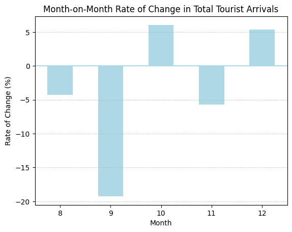

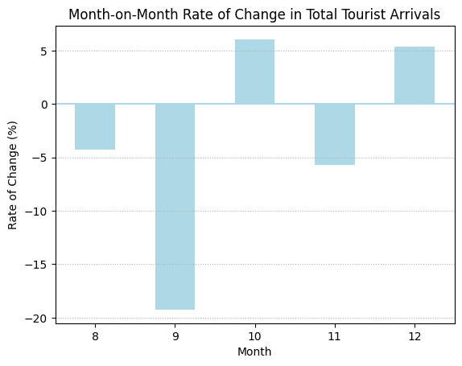

```python
# Type your code here:
q1c.plot(kind = 'bar', x = 'month', y = 'rate',
         legend = False, color = 'lightblue',
         title = 'Month-on-Month Rate of Change in Total Tourist Arrivals',
         xlabel = 'Month', ylabel = 'Rate of Change (%)')
plt.grid(axis = 'y', linestyle = ':')
plt.axhline(y = 0, color = 'lightblue')
plt.xticks(rotation = 0)
plt.show()
```

## 2. Flight Cancellations

In this question, we will use the `flights` and `airports` tables from the `nycflights13` data set.

The files `flights.csv.zip` and `airports.csv` are available in `Canvas > Files > data > nycflights13`.  
Let’s start by reading in the two tables and displaying them.

```python
# data for q2
flights  = pd.read_csv("../data/nycflights13/flights.csv.zip")
airports = pd.read_csv("../data/nycflights13/airports.csv")

show(flights, pageLength = 5, layout={"topStart": None})
show(airports, pageLength = 5, layout={"topStart": None})
```

[figure not shown]

Loading ITables v2.7.0 from the internet... (need [help](https://mwouts.github.io/itables/troubleshooting.html)?)

[figure not shown]

Loading ITables v2.7.0 from the internet... (need [help](https://mwouts.github.io/itables/troubleshooting.html)?)

(A) Filter the `flights` table to keep only flights operated by United Airlines (UA).

- Define a flight to be cancelled if the departure time is missing.
- For each `origin` and `month`, compute the cancellation rate.
- Store the result in a tidy data frame named `q2a`.

The first two rows of `q2a` should look like this:

|  | origin | month | total | cancelled | rate |
| --- | --- | --- | --- | --- | --- |
| 0 | EWR | 1 | 3657 | 21 | 0.574241 |
| 1 | EWR | 2 | 3433 | 131 | 3.815904 |

```python
# Type your code here:
q2a = flights[flights['carrier'] == 'UA'].copy()
q2a = q2a[['origin','month','dep_time']]
q2a['cancelled'] = q2a['dep_time'].isna()
q2a = (
       q2a.groupby(['origin', 'month'])
       .agg(total = ('origin', 'size'), cancelled = ('cancelled', 'sum'))
       .reset_index()
      )
q2a['rate'] = q2a['cancelled']/q2a['total']*100
show(q2a, pageLength = 12, layout={"topStart": None})
```

[figure not shown]

Loading ITables v2.7.0 from the internet... (need [help](https://mwouts.github.io/itables/troubleshooting.html)?)

(B) Join `q2a` with the `airports` table to add the corresponding airport names for each origin airport code.

- Next, pivot the table to wide format so that each airport has its own column listing it's cancellation rates for each month.
- The resulting data frame `q2b` should look like this.

|  | month | John F Kennedy Intl | La Guardia | Newark Liberty Intl |
| --- | --- | --- | --- | --- |
| 0 | Jan | 0.263158 | 1.666667 | 0.574241 |
| 1 | Feb | 4.651163 | 5.799649 | 3.815904 |

- Using `q2b`, re-create, as closely as you can, the following time series line plot to visualize the flight cancellation rates across months for each origin airport.

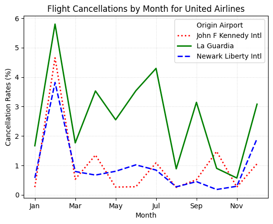

[figure not shown]

Loading ITables v2.7.0 from the internet... (need [help](https://mwouts.github.io/itables/troubleshooting.html)?)

[figure not shown]

Loading ITables v2.7.0 from the internet... (need [help](https://mwouts.github.io/itables/troubleshooting.html)?)

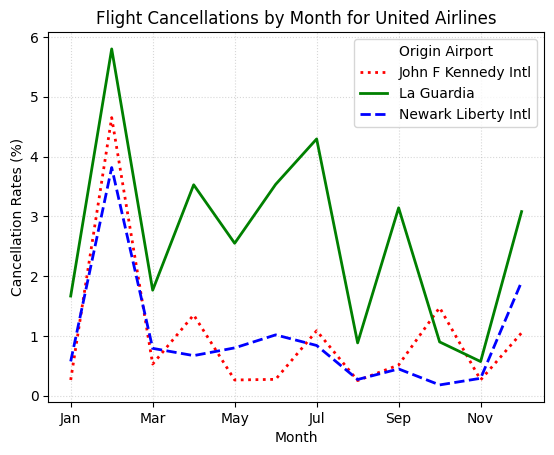

[figure not shown]

Loading ITables v2.7.0 from the internet... (need [help](https://mwouts.github.io/itables/troubleshooting.html)?)

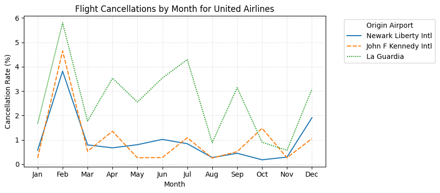

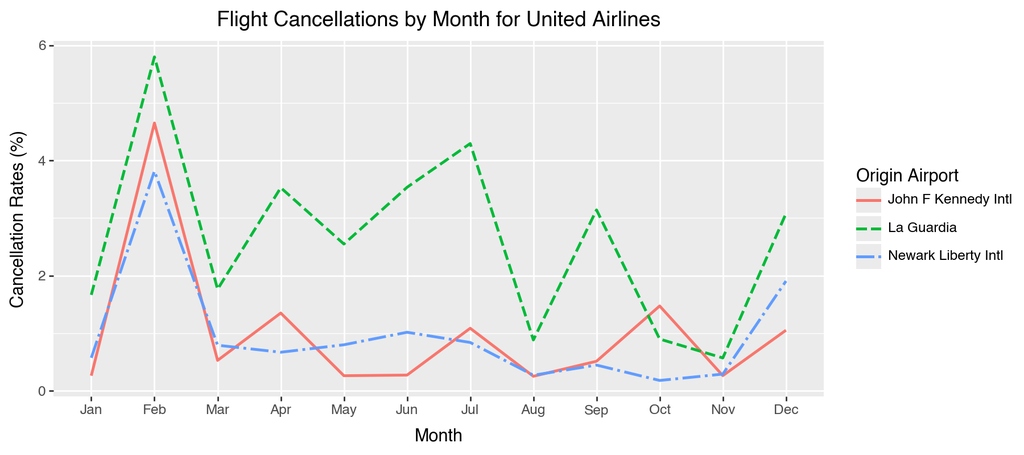

```python
# Type your code here:
q2bt = (
        q2a.merge(
            airports[['faa', 'name']],
            left_on = 'origin', right_on = 'faa', how = 'left'
            )
       ).drop(columns = 'faa')
# note that q2bt is tidy
show(q2bt, pageLength = 12, layout={"topStart": None})

q2b = q2bt.pivot(index = 'month', columns = 'name', values = 'rate').reset_index()
q2b.columns.name = None
q2b['month'] = pd.to_datetime(q2b['month'], format = '%m').dt.strftime('%b')
## note that q2b is not tidy
## but we need it in this form to use pandas or matplotlib
show(q2b, pageLength = 12, layout={"topStart": None})

## -- #### -- #### -- #### -- #### -- #### -- #### -- #### -- #### -- #### -- #### -- ##
## using pandas to make plot
## read https://pandas.pydata.org/docs/reference/api/pandas.DataFrame.plot.line.html
## -- #### -- #### -- #### -- #### -- #### -- #### -- #### -- #### -- #### -- #### -- ##
q2b.plot.line(x = 'month', y = [1,2,3],
              color = ['red', 'green', 'blue'], style = [':', '-', '--'],
              linewidth = 2,
              title = 'Flight Cancellations by Month for United Airlines',
              xlabel = 'Month', ylabel = 'Cancellation Rates (%)')
plt.legend(title = 'Origin Airport')
plt.grid(linestyle = ':', alpha = 0.5)
plt.show()

## -- #### -- #### -- #### -- #### -- #### -- #### -- #### -- #### -- #### -- #### -- ##
## we show code when we work with a tidy frame
## -- #### -- #### -- #### -- #### -- #### -- #### -- #### -- #### -- #### -- #### -- ##

# note that q2bt is tidy
# we now create ordered column for month
q2bt['month'] = pd.to_datetime(q2bt['month'], format = '%m').dt.strftime('%b')
import calendar
month_order = list(calendar.month_abbr)
q2bt['month'] = pd.Categorical(q2bt['month'], categories=month_order, ordered=True)
show(q2bt, pageLength = 5, layout={"topStart": None})

## -- #### -- #### -- #### -- #### -- #### -- #### -- #### -- #### -- #### -- #### -- ##
## using seaborn to make plot
## -- #### -- #### -- #### -- #### -- #### -- #### -- #### -- #### -- #### -- #### -- ##
import seaborn as sns

plt.figure(figsize=(9, 4))

# Use lineplot with 'hue' to create a line for each airport
# this is the key line to make the plot
sns.lineplot(data = q2bt, x = 'month', y = 'rate', hue = 'name', style='name')

# these are just  flourishes
plt.title('Flight Cancellations by Month for United Airlines')
plt.xlabel('Month')
plt.ylabel('Cancellation Rate (%)')
plt.legend(title='Origin Airport', bbox_to_anchor=(1.05, 1), loc='upper left')
plt.grid(True, linestyle=':', alpha=0.6)

plt.tight_layout()
plt.show()

## -- #### -- #### -- #### -- #### -- #### -- #### -- #### -- #### -- #### -- #### -- ##
## using plotnine to make plot
## -- #### -- #### -- #### -- #### -- #### -- #### -- #### -- #### -- #### -- #### -- ##
from plotnine import *

(
    ggplot(q2bt, aes(x = 'month', y = 'rate', group = 'name', color = 'name', linetype='name')) +
    geom_line(size = 1) +
    theme(figure_size=(9, 4)) +
    labs(title = 'Flight Cancellations by Month for United Airlines',
         x = 'Month', y = 'Cancellation Rates (%)', color = 'Origin Airport', linetype = 'Origin Airport')
    )
```